# Project III: IMDB dataset investigation - Felipe Gibert

- Introduction
- Data Wrangling
- Exploratory Data Analysis
- Conclusions

## Introduction

> In this notebook you will find an analysis made over a IMDB dataset that includes the information about around 10.000 movies. The idea of this exercise is to get insight from the information and display them in an intersting way.

```python
#Importing libraries

import pandas as pd
import numpy as np
import matplotlib.pyplot as plt
import seaborn as sns
```

## Data Wrangling

### General Properties

```python
#Loading the data
movies = pd.read_csv("tmdb-movies.csv")

#Making and overview of the data
movies.head(5)
```

|  | id | imdb_id | popularity | budget | revenue | original_title | cast | homepage | director | tagline | ... | overview | runtime | genres | production_companies | release_date | vote_count | vote_average | release_year | budget_adj | revenue_adj |
| --- | --- | --- | --- | --- | --- | --- | --- | --- | --- | --- | --- | --- | --- | --- | --- | --- | --- | --- | --- | --- | --- |
| 0 | 135397 | tt0369610 | 32.985763 | 150000000 | 1513528810 | Jurassic World | Chris Pratt\|Bryce Dallas Howard\|Irrfan Khan\|Vi... | http://www.jurassicworld.com/ | Colin Trevorrow | The park is open. | ... | Twenty-two years after the events of Jurassic ... | 124 | Action\|Adventure\|Science Fiction\|Thriller | Universal Studios\|Amblin Entertainment\|Legenda... | 6/9/15 | 5562 | 6.5 | 2015 | 1.379999e+08 | 1.392446e+09 |
| 1 | 76341 | tt1392190 | 28.419936 | 150000000 | 378436354 | Mad Max: Fury Road | Tom Hardy\|Charlize Theron\|Hugh Keays-Byrne\|Nic... | http://www.madmaxmovie.com/ | George Miller | What a Lovely Day. | ... | An apocalyptic story set in the furthest reach... | 120 | Action\|Adventure\|Science Fiction\|Thriller | Village Roadshow Pictures\|Kennedy Miller Produ... | 5/13/15 | 6185 | 7.1 | 2015 | 1.379999e+08 | 3.481613e+08 |
| 2 | 262500 | tt2908446 | 13.112507 | 110000000 | 295238201 | Insurgent | Shailene Woodley\|Theo James\|Kate Winslet\|Ansel... | http://www.thedivergentseries.movie/#insurgent | Robert Schwentke | One Choice Can Destroy You | ... | Beatrice Prior must confront her inner demons ... | 119 | Adventure\|Science Fiction\|Thriller | Summit Entertainment\|Mandeville Films\|Red Wago... | 3/18/15 | 2480 | 6.3 | 2015 | 1.012000e+08 | 2.716190e+08 |
| 3 | 140607 | tt2488496 | 11.173104 | 200000000 | 2068178225 | Star Wars: The Force Awakens | Harrison Ford\|Mark Hamill\|Carrie Fisher\|Adam D... | http://www.starwars.com/films/star-wars-episod... | J.J. Abrams | Every generation has a story. | ... | Thirty years after defeating the Galactic Empi... | 136 | Action\|Adventure\|Science Fiction\|Fantasy | Lucasfilm\|Truenorth Productions\|Bad Robot | 12/15/15 | 5292 | 7.5 | 2015 | 1.839999e+08 | 1.902723e+09 |
| 4 | 168259 | tt2820852 | 9.335014 | 190000000 | 1506249360 | Furious 7 | Vin Diesel\|Paul Walker\|Jason Statham\|Michelle ... | http://www.furious7.com/ | James Wan | Vengeance Hits Home | ... | Deckard Shaw seeks revenge against Dominic Tor... | 137 | Action\|Crime\|Thriller | Universal Pictures\|Original Film\|Media Rights ... | 4/1/15 | 2947 | 7.3 | 2015 | 1.747999e+08 | 1.385749e+09 |

5 rows × 21 columns

```python
#Checking null values and data types
movies.info()
```

```
<class 'pandas.core.frame.DataFrame'>
RangeIndex: 10866 entries, 0 to 10865
Data columns (total 21 columns):
 #   Column                Non-Null Count  Dtype
---  ------                --------------  -----
 0   id                    10866 non-null  int64
 1   imdb_id               10856 non-null  object
 2   popularity            10866 non-null  float64
 3   budget                10866 non-null  int64
 4   revenue               10866 non-null  int64
 5   original_title        10866 non-null  object
 6   cast                  10790 non-null  object
 7   homepage              2936 non-null   object
 8   director              10822 non-null  object
 9   tagline               8042 non-null   object
 10  keywords              9373 non-null   object
 11  overview              10862 non-null  object
 12  runtime               10866 non-null  int64
 13  genres                10843 non-null  object
 14  production_companies  9836 non-null   object
 15  release_date          10866 non-null  object
 16  vote_count            10866 non-null  int64
 17  vote_average          10866 non-null  float64
 18  release_year          10866 non-null  int64
 19  budget_adj            10866 non-null  float64
 20  revenue_adj           10866 non-null  float64
dtypes: float64(4), int64(6), object(11)
memory usage: 1.7+ MB
```

## Data Cleaning

### We are not planning to develop any analysis related to:

- 'imdb_id' Because we already have and ID column to use
- 'cast' We are no interested in perform any text analysis on this variable
- 'homepage' This column has a los of NaN values, so we prefer not to use it
- 'tagline' We are nos interested to perform a text analysis in this variable
- 'keywords' Same argument used in the tagline column
- 'overview' Same argument related to the text analysis
- 'budget_adj' We have the budget column to perforn analysis related to that
- 'revenue_adj' We have the revenue column to perform the analysis related to that
- 'relase_date' We could use the realse month if we plan to do some analysis related to the date

```python
#Droping the columns that we are not going to use
movies_c = movies.drop(['imdb_id','cast','homepage','tagline','keywords','overview','budget_adj','revenue_adj','release_date'], axis=1)
```

```python
#Checking the new table
movies_c.head(5)
```

|  | id | popularity | budget | revenue | original_title | director | runtime | genres | production_companies | vote_count | vote_average | release_year |
| --- | --- | --- | --- | --- | --- | --- | --- | --- | --- | --- | --- | --- |
| 0 | 135397 | 32.985763 | 150000000 | 1513528810 | Jurassic World | Colin Trevorrow | 124 | Action\|Adventure\|Science Fiction\|Thriller | Universal Studios\|Amblin Entertainment\|Legenda... | 5562 | 6.5 | 2015 |
| 1 | 76341 | 28.419936 | 150000000 | 378436354 | Mad Max: Fury Road | George Miller | 120 | Action\|Adventure\|Science Fiction\|Thriller | Village Roadshow Pictures\|Kennedy Miller Produ... | 6185 | 7.1 | 2015 |
| 2 | 262500 | 13.112507 | 110000000 | 295238201 | Insurgent | Robert Schwentke | 119 | Adventure\|Science Fiction\|Thriller | Summit Entertainment\|Mandeville Films\|Red Wago... | 2480 | 6.3 | 2015 |
| 3 | 140607 | 11.173104 | 200000000 | 2068178225 | Star Wars: The Force Awakens | J.J. Abrams | 136 | Action\|Adventure\|Science Fiction\|Fantasy | Lucasfilm\|Truenorth Productions\|Bad Robot | 5292 | 7.5 | 2015 |
| 4 | 168259 | 9.335014 | 190000000 | 1506249360 | Furious 7 | James Wan | 137 | Action\|Crime\|Thriller | Universal Pictures\|Original Film\|Media Rights ... | 2947 | 7.3 | 2015 |

#### We are going to assume that the first genre that appear in the column genre is the "main" genre ande create a new columnn for that

```python
#Creating a new column
movies_c["Main_genre"] = movies_c.genres.str.split("|",expand = True)[0]
```

#### Then we are going to drop the extra column "genres" because we are not going to use it

```python
#Droping old genre variable
movies_c = movies_c.drop(["genres"],axis=1)
```

```python
#Vizualazing our new values
movies_c.Main_genre.value_counts()
```

```
Drama              2453
Comedy             2319
Action             1590
Horror              915
Adventure           586
Thriller            491
Documentary         432
Animation           403
Crime               381
Fantasy             272
Science Fiction     214
Romance             186
Family              144
Mystery             125
Music               100
TV Movie             78
War                  59
History              44
Western              42
Foreign               9
Name: Main_genre, dtype: int64
```

#### We are going to repeat the previous work but with the production

#### We are going to assume that the first company that appear in the column production_companies is the "main"company and create a new columnn for that.

```python
#Creating the new variable
movies_c["Main_company"] = movies_c.production_companies.str.split("|",expand = True)[0]

#Then we are going to drop the extra column "production_companies" because we are not going to use it
movies_c = movies_c.drop(["production_companies"],axis=1)
```

```python
#Quick check for our new values
movies_c.Main_company.value_counts()
```

```
Universal Pictures                        460
Paramount Pictures                        426
Columbia Pictures                         271
Twentieth Century Fox Film Corporation    242
Walt Disney Pictures                      214
                                         ...
Wild Bear Films                             1
Umedia                                      1
Egoli Tossell Film                          1
Heyday Films                                1
TVE                                         1
Name: Main_company, Length: 3057, dtype: int64
```

```python
#Checking the table one more time
movies_c.head(5)
```

|  | id | popularity | budget | revenue | original_title | director | runtime | vote_count | vote_average | release_year | Main_genre | Main_company |
| --- | --- | --- | --- | --- | --- | --- | --- | --- | --- | --- | --- | --- |
| 0 | 135397 | 32.985763 | 150000000 | 1513528810 | Jurassic World | Colin Trevorrow | 124 | 5562 | 6.5 | 2015 | Action | Universal Studios |
| 1 | 76341 | 28.419936 | 150000000 | 378436354 | Mad Max: Fury Road | George Miller | 120 | 6185 | 7.1 | 2015 | Action | Village Roadshow Pictures |
| 2 | 262500 | 13.112507 | 110000000 | 295238201 | Insurgent | Robert Schwentke | 119 | 2480 | 6.3 | 2015 | Adventure | Summit Entertainment |
| 3 | 140607 | 11.173104 | 200000000 | 2068178225 | Star Wars: The Force Awakens | J.J. Abrams | 136 | 5292 | 7.5 | 2015 | Action | Lucasfilm |
| 4 | 168259 | 9.335014 | 190000000 | 1506249360 | Furious 7 | James Wan | 137 | 2947 | 7.3 | 2015 | Action | Universal Pictures |

#### Adding "Other" category in the Main_company to avoid losing so much data wher droping NaN

```python
#Chaging NaN for Other no have a cleaner analysis
movies_c["Main_company"] = movies_c["Main_company"].replace(np.NaN,"Other")
```

```python
movies_c.info()
```

```
<class 'pandas.core.frame.DataFrame'>
RangeIndex: 10866 entries, 0 to 10865
Data columns (total 12 columns):
 #   Column          Non-Null Count  Dtype
---  ------          --------------  -----
 0   id              10866 non-null  int64
 1   popularity      10866 non-null  float64
 2   budget          10866 non-null  int64
 3   revenue         10866 non-null  int64
 4   original_title  10866 non-null  object
 5   director        10822 non-null  object
 6   runtime         10866 non-null  int64
 7   vote_count      10866 non-null  int64
 8   vote_average    10866 non-null  float64
 9   release_year    10866 non-null  int64
 10  Main_genre      10843 non-null  object
 11  Main_company    10866 non-null  object
dtypes: float64(2), int64(6), object(4)
memory usage: 1018.8+ KB
```

#### Taking out the rows where are missing values to avoid future problems or miss understandings

```python
#Droping the rows with NaN
movies_f = movies_c.dropna()
movies_f.info()
```

```
<class 'pandas.core.frame.DataFrame'>
Int64Index: 10801 entries, 0 to 10865
Data columns (total 12 columns):
 #   Column          Non-Null Count  Dtype
---  ------          --------------  -----
 0   id              10801 non-null  int64
 1   popularity      10801 non-null  float64
 2   budget          10801 non-null  int64
 3   revenue         10801 non-null  int64
 4   original_title  10801 non-null  object
 5   director        10801 non-null  object
 6   runtime         10801 non-null  int64
 7   vote_count      10801 non-null  int64
 8   vote_average    10801 non-null  float64
 9   release_year    10801 non-null  int64
 10  Main_genre      10801 non-null  object
 11  Main_company    10801 non-null  object
dtypes: float64(2), int64(6), object(4)
memory usage: 1.1+ MB
```

# Exploratory Data Analysis

## General topics about the movies

### Max, Min and average budget

```python
#Movies with the biggest budget
max_budget = movies_f["budget"].max()
movies_f.loc[movies_f['budget'] == max_budget]

#Movies with the smallest budget
min_budget = movies_f["budget"].min() #As the minimum budget is zero, we need to find a minimum budget that is not zero
movies_f_min_b = movies_f.loc[(movies_f['budget'] == min_budget)]
movies_f_min_b

# As the mininum budget could not be 1, we need to look for a realistic number like 100,000
movies_100 = movies_f.loc[(movies_f['budget'] >= 100000)]
movies_100 = movies_100.sort_values("budget",ignore_index = True)
movies_100.iloc[0]

# Average Budget
avg_budget =  movies_f["budget"].mean()
avg_budget

print("The max budget found for a movies is {} dolars, the minimum budget in the data is {} dolars and the average budget is {} dolars".format(max_budget,min_budget,round(int(avg_budget),0)))
```

```
The max budget found for a movies is 425000000 dolars, the minimum budget in the data is 0 dolars and the average budget is 14712552 dolars
```

### Max,min and average revenue

```python
#Movies with the biggest revenue
max_rev = movies_f["revenue"].max()
movies_f.loc[movies_f['revenue'] == max_rev] #Movies with the biggest revenue

#Movies with the smallest revenue
min_rev = movies_f["revenue"].min()
movies_f_min_r = movies_f.loc[(movies_f['revenue'] == min_rev)] #Movies with the biggest revenue
movies_f_min_r

# Average Budget
avg_rev =  movies_f["revenue"].mean()

print("The max revenue found for a movies is {} dolars, the minimum revenue in the data is {} dolars and the average revenue is {}".format(max_rev,min_rev,round(int(avg_rev),0) ))
```

```
The max revenue found for a movies is 2781505847 dolars, the minimum revenue in the data is 0 dolars and the average revenue is 40061956
```

### Max,min and average Popularity

#### While analizing the dataset I notice that somethings weird is happening with popularity

#### It is not really clear how it is calculated, so for this reason I choose to a new variable to analyze popularity

```python
movies_f["weighted_popularity"] = round(((movies_f["vote_average"]*movies_f["vote_count"])/movies_f["vote_count"].sum())*100000,2)
```

```python
#Movies with the biggest popularity
max_pop = movies_f["weighted_popularity"].max()
movies_f.loc[movies_f["weighted_popularity"] == max_pop] #Movies with the biggest popularity

#Movies with the smallest popularity
min_pop = movies_f["weighted_popularity"].min()
movies_f_min_p = movies_f.loc[(movies_f["weighted_popularity"] == min_pop)] #Movies with the biggest revenue
movies_f_min_p

# Average Budget
avg_pop =  movies_f["weighted_popularity"].mean()

print("The max popularity score found for a movies is {} , the minimum popularity score in the data is {}  and the average popularity is {}".format(max_pop,min_pop,round(avg_pop,0)))
```

```
The max popularity score found for a movies is 3268.08 , the minimum popularity score in the data is 0.64  and the average popularity is 61.0
```

```python
#we can also clasify a movie based on their popularity score
size_range_pop = round((max_pop - min_pop)/5)
size_range_pop

def get_pop(row):
    if row >= 0 and row < 653:
        return "Not popular"
    elif row >= 653 and row < 1306:
        return "Kinda not popular"
    elif row >= 1306 and row < 1959:
        return "Half Popular"
    elif row >= 1959 and row < 2612:
        return "Popular"
    elif row >= 2612 and row < 3270:
        return "Really popular"

movies_f["Clasification"] = movies_f["weighted_popularity"].apply(get_pop)
```

#### With this information we can check the popularity of the movies by category

```python
movies_f.groupby(["Clasification"])["id"].count()
# With this we can notices that a lot of movies are really low rated in the plataform and only few movies are really popular
```

```
Clasification
Half Popular            28
Kinda not popular      154
Not popular          10606
Popular                 10
Really popular           3
Name: id, dtype: int64
```

```python
#Would be interesting to see what movies are really popular
movies_f.query("Clasification == 'Really popular'") #really popular movies
```

|  | id | popularity | budget | revenue | original_title | director | runtime | vote_count | vote_average | release_year | Main_genre | Main_company | weighted_popularity | Clasification |
| --- | --- | --- | --- | --- | --- | --- | --- | --- | --- | --- | --- | --- | --- | --- |
| 1919 | 27205 | 9.363643 | 160000000 | 825500000 | Inception | Christopher Nolan | 148 | 9767 | 7.9 | 2010 | Action | Legendary Pictures | 3268.08 | Really popular |
| 2875 | 155 | 8.466668 | 185000000 | 1001921825 | The Dark Knight | Christopher Nolan | 152 | 8432 | 8.1 | 2008 | Drama | DC Comics | 2892.81 | Really popular |
| 4361 | 24428 | 7.637767 | 220000000 | 1519557910 | The Avengers | Joss Whedon | 143 | 8903 | 7.3 | 2012 | Science Fiction | Marvel Studios | 2752.73 | Really popular |

### Question 1: How the genre of a movie is related to the budget, revenue, popularity?

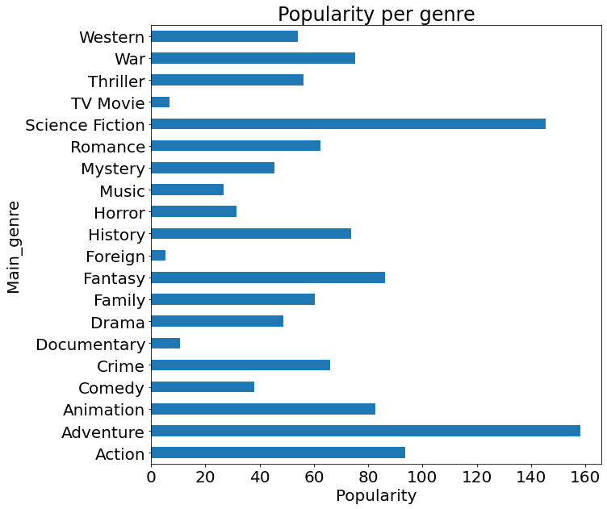

```python
# Genre and popularity
genre_pop =movies_f.groupby(["Main_genre"])["weighted_popularity"].mean()

plt.title("Popularity per genre")
plt.xlabel("Popularity")
plt.ylabel("Movie main genre")

genre_pop.plot(kind = 'barh',figsize = (10,10));
```

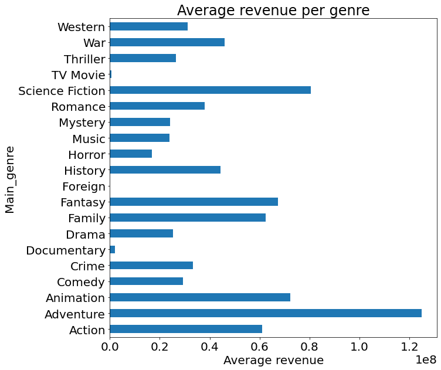

```python
# Genre and revenue
genre_rev =movies_f.groupby(["Main_genre"])["revenue"].mean()

plt.title("Average revenue per genre")
plt.xlabel("Average revenue")
plt.ylabel("Movie main genre")

genre_rev.plot(kind = 'barh',figsize = (10,10));
```

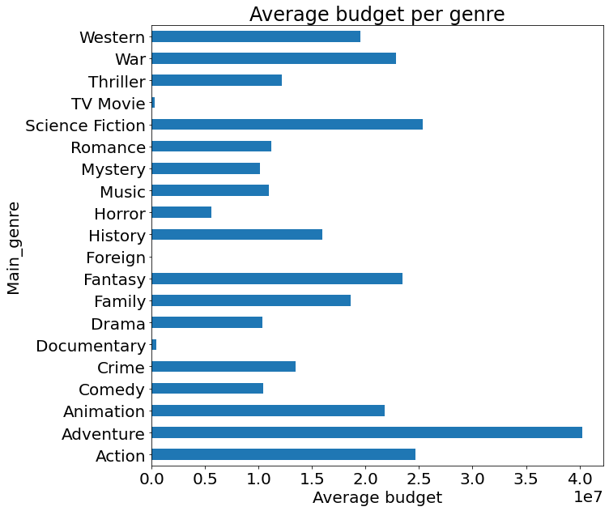

```python
# Genre and revenue
genre_budget =movies_f.groupby(["Main_genre"])["budget"].mean()

plt.title("Average budget per genre")
plt.xlabel("Average budget")
plt.ylabel("Movie main genre")

genre_budget.plot(kind = 'barh',figsize = (10,10));
```

### Question 2: How the director is related with the budget, revenue,popularity and the number of movies ?

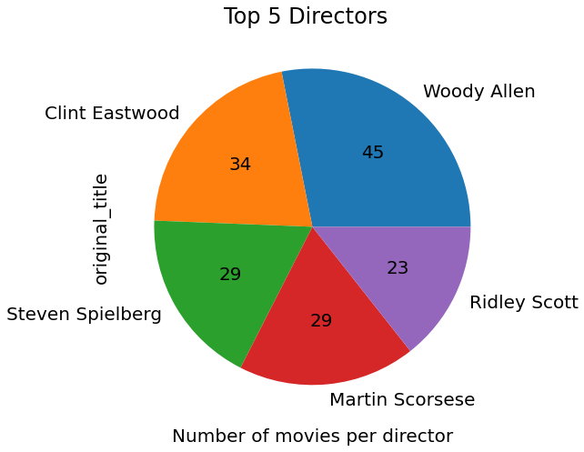

```python
def make_autopct(values):
    def my_autopct(pct):
        total = sum(values)
        val = int(round(pct*total/100.0))
        return '{v:d}'.format(v=val)
    return my_autopct

#Top 5 directors
director_movie =movies_f.groupby(["director"])["original_title"].count()
director_movie.sort_values(ascending = False)
Top5_Directors = director_movie.sort_values(ascending = False).iloc[0:5]

plt.rcParams['font.size'] = 20
plt.title("Top 5 Directors  ")
plt.xlabel("Number of movies per director")


Top5_Directors.plot(kind = 'pie',figsize = (8,8), autopct=make_autopct(Top5_Directors));
#
```

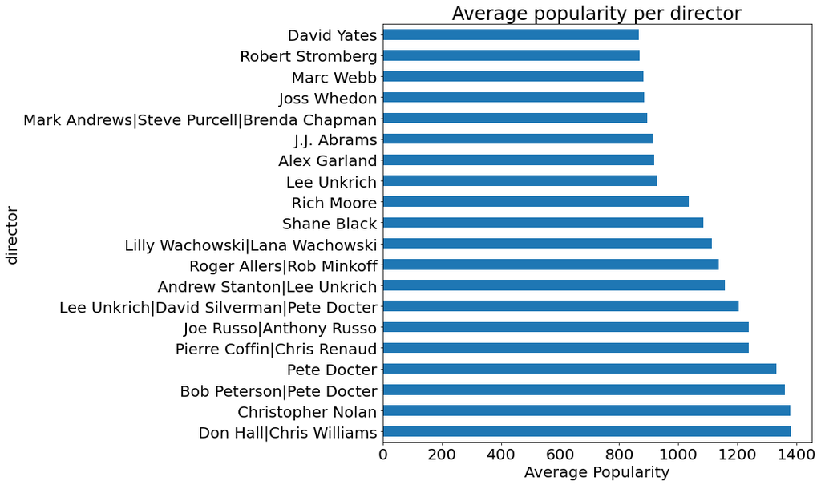

```python
# Director and popularity
dir_pop =movies_f.groupby(["director"])["weighted_popularity"].mean()

Top20_Pop = dir_pop.sort_values(ascending = False).iloc[0:20]

plt.title("Average popularity per director")
plt.xlabel("Average Popularity")
plt.ylabel("Director")

Top20_Pop.plot(kind = 'barh',figsize = (10,10));
```

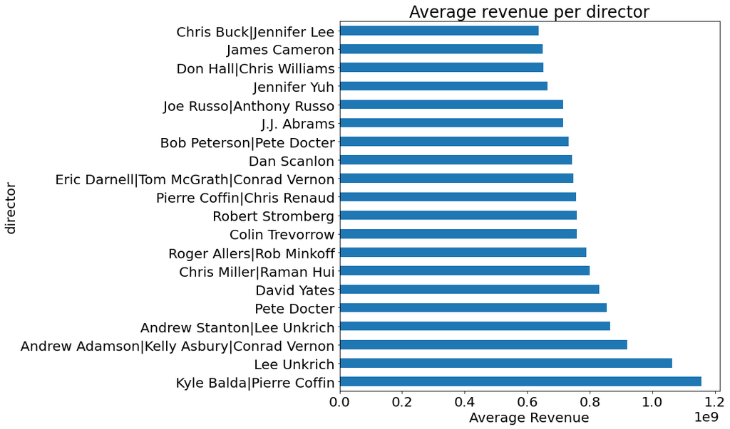

```python
# Director and revenue
dir_rev =movies_f.groupby(["director"])["revenue"].mean()

Top20_Rev = dir_rev.sort_values(ascending = False).iloc[0:20]

plt.title("Average revenue per director")
plt.xlabel("Average Revenue")
plt.ylabel("Director")

Top20_Rev.plot(kind = 'barh',figsize = (10,10));
```

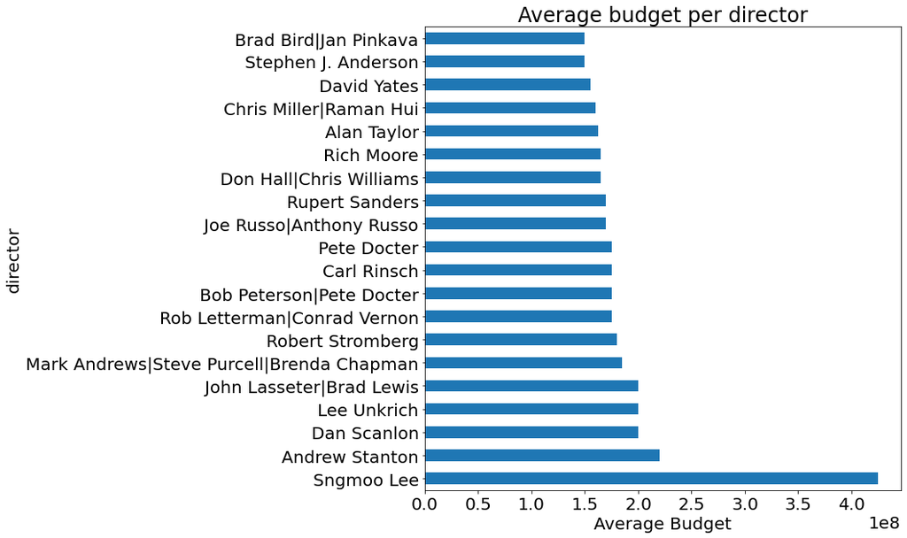

```python
# Director and revenue
dir_bud =movies_f.groupby(["director"])["budget"].mean()

Top20_bud = dir_bud.sort_values(ascending = False).iloc[0:20]

plt.title("Average budget per director")
plt.xlabel("Average Budget")
plt.ylabel("Director")

Top20_bud.plot(kind = 'barh',figsize = (10,10));
```

### Question 3: Is there any correlation between the variables?

```python
#Checking the correlation of the variables
corr = movies_f.corr()
corr
```

|  | id | popularity | budget | revenue | runtime | vote_count | vote_average | release_year | weighted_popularity |
| --- | --- | --- | --- | --- | --- | --- | --- | --- | --- |
| id | 1.000000 | -0.011770 | -0.139936 | -0.098140 | -0.084534 | -0.033960 | -0.064319 | 0.511186 | -0.033467 |
| popularity | -0.011770 | 1.000000 | 0.544858 | 0.663094 | 0.140527 | 0.800710 | 0.213040 | 0.091347 | 0.795249 |
| budget | -0.139936 | 0.544858 | 1.000000 | 0.734685 | 0.193883 | 0.632373 | 0.083584 | 0.117470 | 0.593939 |
| revenue | -0.098140 | 0.663094 | 0.734685 | 1.000000 | 0.165239 | 0.791028 | 0.175052 | 0.058068 | 0.769311 |
| runtime | -0.084534 | 0.140527 | 0.193883 | 0.165239 | 1.000000 | 0.165720 | 0.165164 | -0.117172 | 0.166891 |
| vote_count | -0.033960 | 0.800710 | 0.632373 | 0.791028 | 0.165720 | 1.000000 | 0.256777 | 0.109129 | 0.994675 |
| vote_average | -0.064319 | 0.213040 | 0.083584 | 0.175052 | 0.165164 | 0.256777 | 1.000000 | -0.122550 | 0.275372 |
| release_year | 0.511186 | 0.091347 | 0.117470 | 0.058068 | -0.117172 | 0.109129 | -0.122550 | 1.000000 | 0.095489 |
| weighted_popularity | -0.033467 | 0.795249 | 0.593939 | 0.769311 | 0.166891 | 0.994675 | 0.275372 | 0.095489 | 1.000000 |

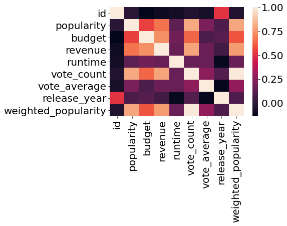

```python
#Creating a heatmap for better understanding
heat_map = sns.heatmap(corr)
```

## Conclusions

[output not shown]

The minimum budget and revenue situation could mean that they start as a free budget/revenue movie or the data is incomplete. in this case we are goingt to asume the second option.